# Reproducible Research: Peer Assessment 1

## Loading and preprocessing the data

```r
activity <- read.csv("activity.csv")
```

## What is mean total number of steps taken per day?

Total numbers of steps taken per day

```r
steps_d <- with(activity, tapply(steps, date, sum, na.rm = TRUE))
```

Histogram of total steps taken per day

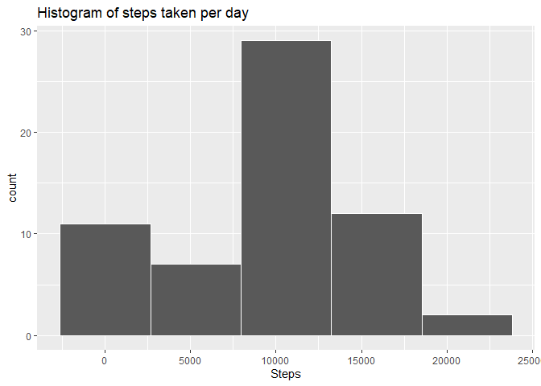

```r
library(ggplot2)
ggplot()+geom_histogram(aes(steps_d), bins=5, color="White") + ggtitle("Histogram of steps taken per day") + xlab("Steps")
```

Mean value of the total number of steps per day

```r
mean(steps_d)
```

```
## [1] 9354.23
```

Median value of the total number of steps per day

```r
median(steps_d)
```

```
## [1] 10395
```

## What is the average daily activity pattern?

Time series plot of the average number of steps taken in 5-minute interval

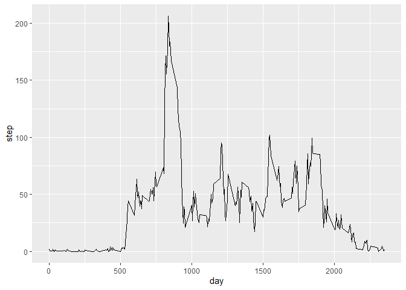

```r
steps_daily <- with(activity, tapply(steps, interval, mean, na.rm = TRUE))
library(ggplot2)
ggplot(data.frame(day = as.numeric(names(steps_daily)), step = steps_daily)) + geom_line(aes(day, step))
```

The 5-minute interval contains maximum number of steps on average across all the days

```r
names(which.max(steps_daily))
```

```
## [1] "835"
```

## Imputing missing values

Total Number of rows contains at least one NA

```r
sum(!complete.cases(activity))
```

```
## [1] 2304
```

```r
activity_imp <- activity
for(i in seq_len(nrow(activity_imp))){
        if(is.na(activity_imp[i, "steps"])){
                activity_imp[i, "steps"] <- steps_d[activity_imp[i, "date"]]
        }
}
```

Total numbers of steps taken per day

```r
steps_d_imp <- with(activity_imp, tapply(steps, date, sum, na.rm = TRUE))
```

Histogram of total steps taken per day

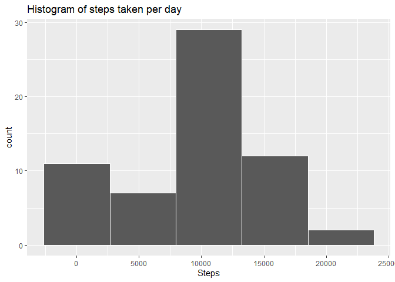

```r
#hist(steps_d_imp, main = ("Histogram of steps taken per day"), xlab = "Steps")
library(ggplot2)
ggplot()+geom_histogram(aes(steps_d_imp), bins=5, color="White") + ggtitle("Histogram of steps taken per day") + xlab("Steps")
```

Mean value of the total number of steps per day

```r
mean(steps_d_imp)
```

```
## [1] 9354.23
```

Median value of the total number of steps per day

```r
median(steps_d_imp)
```

```
## [1] 10395
```

## Are there differences in activity patterns between weekdays and weekends?

A new factor variable in the dataset with two levels - “weekday” and “weekend” Add the factor to a new colume “week” into the activity_imp

```r
weekend <- c("Saturday", "Sunday")
activity_imp$week <- factor((weekdays(as.Date(activity_imp$date)) %in% weekend), levels = c(FALSE, TRUE), labels = c("Weekday", "Weekend"))
```

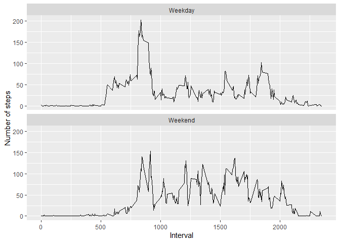

```r
steps_dailyw <- with(activity_imp, aggregate(steps, list(interval, week), mean, na.rm = TRUE))

library(ggplot2)
ggplot(steps_dailyw, aes(Group.1, x)) + geom_line(aes(group = Group.2)) + facet_wrap(vars(Group.2), nrow = 2) + xlab("Interval") + ylab("Number of steps")
```